# Basic Tools For Forecasting

# Time Series Plot for the First Differences of the Dulles Passenger Series

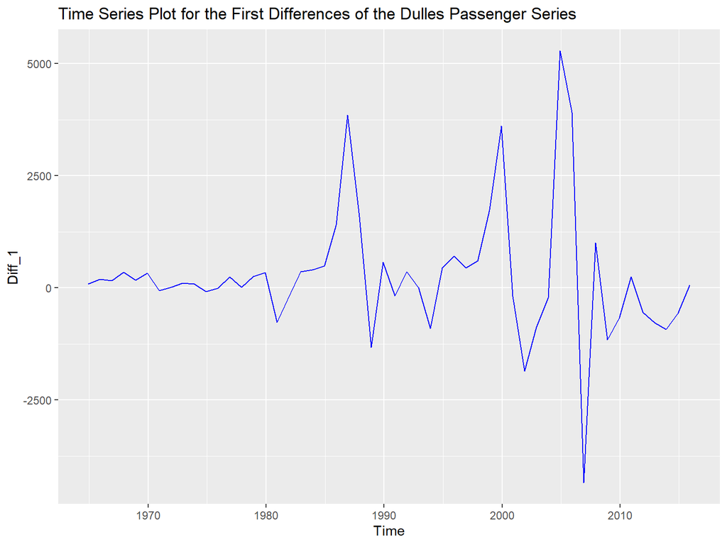

```r
# How to use "diff" function
library(ggplot2)
par(mfrow=c(1,2))
Diff_1 <- diff(Dulles2, differences = 1)
autoplot(Diff_1, xlab='Time', colour="blue",main = "Time Series Plot for the First Differences of the Dulles Passenger Series")
```

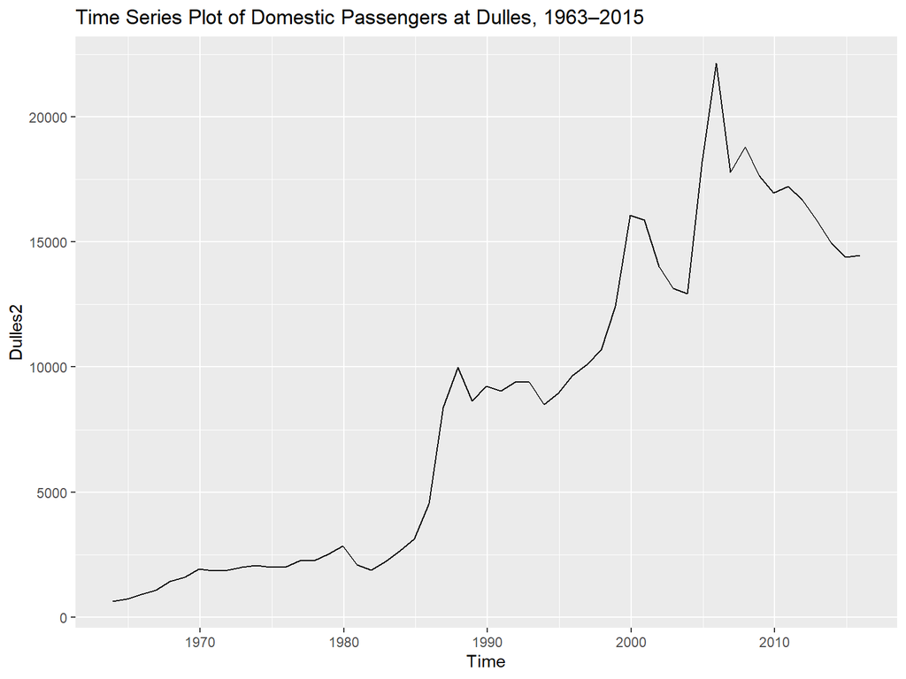

```r
autoplot(Dulles2, xlab='Time',main = "Time Series Plot of Domestic Passengers at Dulles, 1963–2015")
```

# Tips

- First-differencing a time series will remove a linear trend (i.e., differences=1).
- First-differencing a time series at a lag equal to the period will remove a seasonal trend (e.g., set lag=12 for monthly data).
- Twice-differencing will remove a quadratic trend (i.e., differences=2).

# Basics of Mathematical Notation for Time Series (Time Lag)

$y_{t-j}$: jth lag of y

$y_{t-j}$: the value of y in time period t-j (the value of j periods earlier).

- $\Delta y_t=y_t - y_{t-1}$
- $\Delta y_{t-1} = y_{t-1} - y_{t-2}$
- $\Delta y_{t-j}=y_{t-j}-y_{t-j-1}$

Each time we lag a time series one period we lose an observation.

Each time we difference a time series we lose an observation.